# Explanatory Analysis on Craft Beers

```python
import pandas as pd #For reading data from files into table
import numpy as np #For computing maths on data columns
from matplotlib import pyplot as plt #For plotting basic graphs. Also provides indepth framework for seaborn
import seaborn as sns #For plotting visually asthetic graphs. Works in tandem with matplotlib's pyplot
```

```python
sns.set_style("darkgrid")
plt.rcParams.update(plt.rcParamsDefault)
%matplotlib inline
```

# Gather

For this project we would be considering the Kaggle dataset on beers and breweries they originate from.

```python
#Loading Cleaned Dataset
df_beer = pd.read_csv('Merged_Final.csv')
```

# Analyze

```python
df_copy= df_beer.copy()
```

```python
#Considering the top 10 beer styles by count
top_10_beer = df_copy['Beer Style'].value_counts()[0:10].index
df_beer_sub = df_copy[df_copy['Beer Style'].isin(top_10_beer)]


#Considering the top 20 Breweries by count
top_20_breweries = df_copy['Brewery Name'].value_counts()[0:15].index
df_brewery_sub = df_copy[df_copy['Brewery Name'].isin(top_20_breweries)]


#Considering the top 10 States of Breweries by count
top_10_state = df_copy['Brewery State'].value_counts()[0:10].index #Soring the index as an ordered series for ranking
df_state_sub = df_copy[df_copy['Brewery State'].isin(top_10_state)] #Keeping only the rows with the Brewery State in the top 10 states
```

## Spread of IBU for top 10 beers

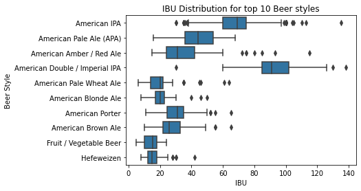

```python
#defining color palette for seaborn plots

color = sns.color_palette()[0]
# Plotting a boxplot to see the distribution of the IBU for the top 10 beer styles
sns.boxplot(data=df_beer_sub, y='Beer Style', x='IBU', order=top_10_beer, color=color)
plt.title("IBU Distribution for top 10 Beer styles");
```

Looks like the American IPA is the second most bitter beer after American Double / Imperial IPA. Would be interesting to see the ABV vs. IBU for each of the beers

## Spread of ABV for top 10 beers

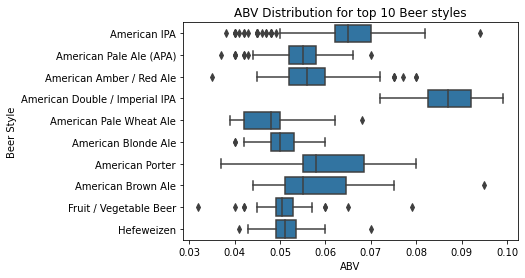

```python
# Plotting a boxplot to see the distribution of the ABV for the top 10 beer styles
sns.boxplot(data=df_beer_sub, y='Beer Style', x='ABV', order=top_10_beer, color=color)
plt.title("ABV Distribution for top 10 Beer styles");
```

In terms of the alcohol percent, it seems American Double / Imperial IPA is one of the highest with American IPA having the second highest median followed by American Porter.

## Serving size for top 10 beers

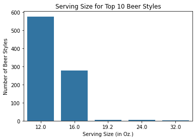

```python
sns.countplot(data=df_beer_sub, x='Serving Size (in Oz.)', color=color)
plt.ylabel('Number of Beer Styles')
plt.title("Serving Size for Top 10 Beer Styles")
```

Majority of the Top 10 Beer Styles are either served in 12 Ounces or 16 Ounces with barely a few being served in 19.2, 24 or 32 Ounces.

## ABV vs IBU for Top 10 Beer Styles

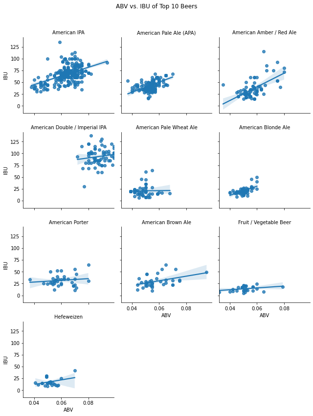

```python
g = sns.FacetGrid(data=df_beer_sub, col='Beer Style', col_wrap=3,height=3, col_order=top_10_beer)
g.map(sns.regplot, "ABV", "IBU")
g.set_titles('{col_name}')
g.fig.suptitle('ABV vs. IBU of Top 10 Beers')
g.fig.subplots_adjust(top=0.9)
```

Interestingly, IBU seems to be a function of ABV and the type of beer styles. In simple words, the IBU of a beer can be determined based on the ABV of a beer and it's beer style.

## ABV vs IBU for 3 Most Popular Beer Styles

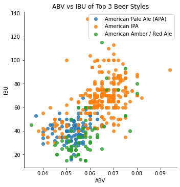

```python
#Creating a dataframe of top 3 beer styles
df_beer_sub_sub = df_beer_sub[df_beer_sub['Beer Style'].isin(top_10_beer[:3])]
#Creating a FacetGrid with beer style as a hue
g = sns.FacetGrid(data=df_beer_sub_sub, hue='Beer Style', height=5)
#Mapping a regression plot (scatter plot) of ABV vs IBU
g.map(sns.regplot, "ABV", "IBU", fit_reg=False)
g.set_titles('{col_name}')
#Changing the xticks for better visualization
#xticks = [0.03, 0.04, 0.06, 0.08, 0.1]
plt.xscale('linear')
#plt.xticks(xticks, labels=xticks)
# plt.yscale('log')
#Adding the legend
plt.legend()
#Adding Plot Title
plt.title("ABV vs IBU of Top 3 Beer Styles")
```

This particular graph further helps us in understanding that the IBU is a function of the Beer style and the ABV content it has. It can be said otherwise too, meaning, ABV can be determined based on the IBU and the style of the beer.

## Serving Size for Top 10 Most Popular Beer Styles

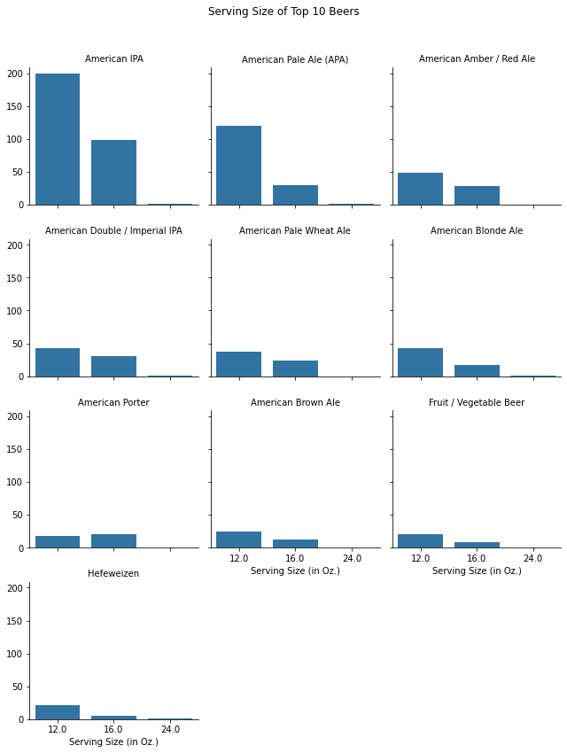

```python
g = sns.FacetGrid(data=df_beer_sub, col='Beer Style', col_wrap=3,size=3, col_order=top_10_beer)
g.map(sns.countplot, "Serving Size (in Oz.)")
g.set_titles('{col_name}')
g.fig.suptitle('Serving Size of Top 10 Beers')
g.fig.subplots_adjust(top=.9)
```

## ABV vs. IBU for Top 10 States by number of different Craft Beers

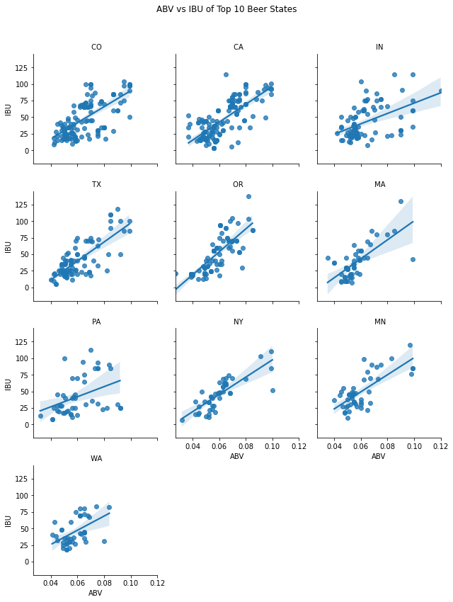

```python
g = sns.FacetGrid(data=df_state_sub, col='Brewery State', col_wrap=3,height=3, col_order=top_10_state, sharex=True)
g.map(sns.regplot, "ABV", "IBU")
g.set_titles('{col_name}')
g.fig.suptitle('ABV vs IBU of Top 10 Beer States')
g.fig.subplots_adjust(top=0.9);
```

This particular graph helps us in understanding that the IBU and ABV are not dependent on the state they are in.

## Top Beer Styles for Top 10 States by number of different Craft Beers

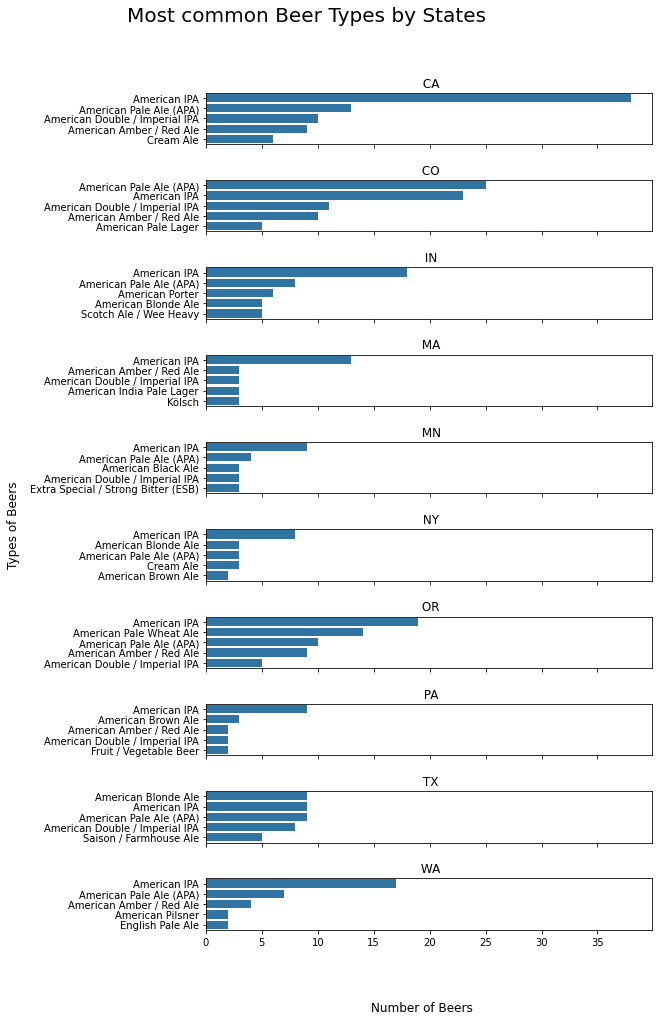

```python
# Top beers in each state
# First we group by the Brewery State and the Beer Style
df_gb = df_state_sub.groupby(['Brewery State','Beer Style'])['Brewery City'].count().reset_index()
# We would like to get the top 5 beer styles in each of these states
df_gb = df_gb.groupby('Brewery State').apply(lambda grp: grp.nlargest(5, 'Brewery City'))
#Removing the Multi Indexing
df_gb.reset_index(drop=True, inplace=True)

#Plotting
#Creating a figure subplot object
fig, axs = plt.subplots(10,1, figsize=(8,15), sharex=True)
#Flattening the axis
axs = axs.ravel()
#Adjusting the subplot placement
fig.subplots_adjust(top =0.9,wspace=0.5, hspace=0.7)
#Title for the whole plot
fig.suptitle("Most common Beer Types by States", fontsize=20, x=0.3)
#X axis title
fig.text(0.5, 0.05, 'Number of Beers', ha='center', fontsize=12)
#Y axis title
fig.text(-0.22, 0.5, 'Types of Beers', va='center', rotation='vertical', fontsize=12)
#Iterating over each of the subplots
for i in range(10):
    g= sns.barplot(data=df_gb.iloc[i*5: (i*5)+5], y="Beer Style", x="Brewery City", ax=axs[i], color=color)
    #Naming each of the subplots with the corresponding state name
    axs[i].title.set_text(df_gb.iloc[i*5: (i*5)+5]['Brewery State'].unique()[0])
    #Removing the individual x label and y label
    g.set(xlabel="", ylabel="")
```

## Distribution of Serving Size in Top 10 States

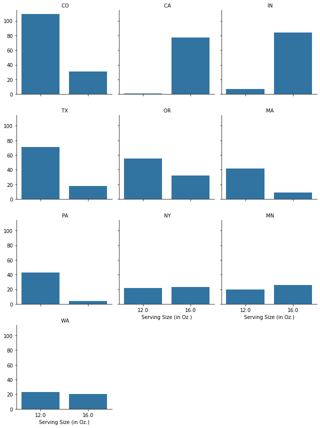

```python
g = sns.FacetGrid(data=df_state_sub, col='Brewery State', col_wrap=3,size=3, col_order=top_10_state, sharey=True)
g.map(sns.countplot, "Serving Size (in Oz.)")
g.set_titles('{col_name}');
```

California and Indiana do not like the 12 Ounces Serving looks like. They much prefer the 16 Ounces beer serving.

All in all, depending on the style of beer we can determine which state should it be most suited for. The other way around is true as well. We can determine in which states which beers would do well.

**Limitations:**  
The dataset is based on a limited number of craft beers. It does not account for the whole list of craft beers available across United States.